# Report

## 0. 데이터셋 설명(100대 생활업종 명세)

100개의 업종 별로 시/도의 시군구로 나누어 당월과 전월의 사업자 수를 비교한 증감율과 전년도와 동월과의 사업자 수를 비교한 증감율을 나타내는 데이터셋이다. 또한 시군구 별 사업자 수 증감율 또한 나타나 있다.

```python
import pandas as pd
import matplotlib as mpl
import matplotlib.pyplot as plt
import numpy as np
```

## 1. 지역별 사업자 현황

```python
data = pd.read_csv('100.csv')

data_set = data[(data['업종'] == '업종전체')]
data_set = data_set[(data_set['시도'] != '합계')]
data_set = data_set[(data_set['시군구'] != '합계')]

first_data_set = data_set['날짜']
second_data_set = data_set['시도']
third_data_set = data_set['시군구']
fourth_data_set = data_set['당월']

fifth_data_set = pd.merge(first_data_set, second_data_set, left_index = True, right_index = True)
sixth_data_set = pd.merge(third_data_set, fourth_data_set, left_index = True, right_index = True)

result = pd.merge(fifth_data_set, sixth_data_set, left_index = True, right_index = True)

print(result.values)
```

```
[['2019_01' '서울특별시' '종로구' '16,497']
 ['2019_01' '서울특별시' '중구' '18,154']
 ['2019_01' '서울특별시' '용산구' '13,222']
 ...
 ['2020_12' '경상남도' '합천군' '1,769']
 ['2020_12' '제주특별자치도' '제주시' '34,259']
 ['2020_12' '제주특별자치도' '서귀포시' '13,131']]
```

## 2. 업종별 사업자 현황

```python
data = pd.read_csv('100.csv')

data = data[(data['업종'] != '업종전체')]
data = data[(data['시도'] == '합계')]
data = data[(data['시군구'] == '합계')]

first = data['날짜']
second = data['업종']
third = data['당월']

fourth = pd.merge(first, second, left_index = True, right_index = True)
fifth = pd.merge(fourth, third, left_index = True, right_index = True)

result = pd.DataFrame(fifth)

print(result)
```

```
             날짜       업종       당월
269     2019_01      가구점    7,450
537     2019_01  가전제품수리점   13,299
806     2019_01  가전제품판매점    9,817
1075    2019_01     간이주점   15,649
1341    2019_01   간판광고물업   12,897
...         ...      ...      ...
619918  2020_12    한식전문점  397,465
620186  2020_12     헬스클럽    8,569
620443  2020_12    호프전문점   29,002
620711  2020_12    화장품가게   35,004
620979  2020_12    휴대폰가게   18,737

[2400 rows x 3 columns]
```

## 3. 지역별 주요 업종 비교

```python
import copy
data = pd.read_csv('100.csv', sep=',', error_bad_lines=False, index_col=False, dtype='unicode') # 메모리 에러가 자꾸 떠서 검색해서 추가

for i in range(2):

    if i == 0:
        first = copy.deepcopy(data[data['날짜'] == '2019_01'])
    else:
        first = copy.deepcopy(data[data['날짜'] == '2020_12'])

    second = copy.deepcopy(first[first['업종'] != '업종전체'])
    third = copy.deepcopy(second[second['시도'] != '합계'])
    fourth = copy.deepcopy(third[third['시군구'] == '합계'])
    result = copy.deepcopy(fourth[fourth['당월'] != '*'])

    result['당월'].str.replace(',','').astype('int64')
    result['당월'] = result['당월'].str.replace(',','').astype('int64')

    print(result[['날짜', '시도', '업종', '당월']].loc[result.groupby(['시도'])['당월'].idxmax()])
```

```
            날짜       시도     업종     당월
24153  2019_01      강원도  한식전문점  19271
24110  2019_01      경기도  한식전문점  77957
24314  2019_01     경상남도  한식전문점  31752
24266  2019_01     경상북도  한식전문점  29086
24212  2019_01    광주광역시  한식전문점   9558
24257  2019_01    대구광역시  한식전문점  19565
24172  2019_01    대전광역시  한식전문점  11507
24291  2019_01    부산광역시  한식전문점  23703
22253  2019_01    서울특별시  통신판매업  67142
24210  2019_01  세종특별자치시  한식전문점   1928
24308  2019_01    울산광역시  한식전문점  10801
24098  2019_01    인천광역시  한식전문점  17058
24234  2019_01     전라남도  한식전문점  17262
24218  2019_01     전라북도  한식전문점  13973
```

[output cut: 21 more lines]

## 4. 코로나 전후의 사업자수 변화

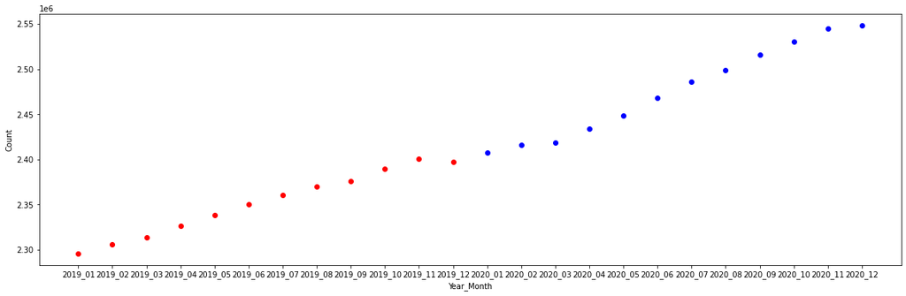

```python
data = pd.read_csv('100.csv', sep=',', error_bad_lines=False, index_col=False, dtype='unicode')

first = data[data['업종'] == '업종전체']
second = first[first['시도'] == '합계']
result = second[second['시군구'] == '합계']

result['당월'] = result['당월'].str.replace(',', '').astype('int64')

plt.figure(figsize = (20, 6))
plt.xlabel('Year_Month')
plt.ylabel('Count')
plt.plot(result['날짜'][:12], result['당월'][:12], 'or')
plt.plot(result['날짜'][12:], result['당월'][12:], 'ob')
plt.show()
```

## 5. 코로나 이후 감소한 업종

```python
data = pd.read_csv('100.csv', sep=',', error_bad_lines=False, index_col=False, dtype='unicode')

first = data[(data['업종'] != '업종전체')]
second = first[first['날짜'].str.contains('2020')]
third = second[(second['시도'] == '합계')]
result = third[(third['증감율(전년동월)'].str.replace('%', '').astype('float32') < 100)] # 100프로는 제외

print(result[['날짜', '업종', '증감율(전년동월)']])
print(result['업종'].values.tolist())
```

```
             날짜      업종 증감율(전년동월)
311152  2020_01     PC방    96.26%
312221  2020_01    간이주점    91.43%
313955  2020_01    곡물가게    99.40%
315375  2020_01    구내식당    92.86%
316660  2020_01   기타음식점    96.27%
...         ...     ...       ...
612075  2020_12     옷가게    98.44%
614164  2020_12  자전거판매점    99.88%
614422  2020_12   장난감가게    98.10%
616767  2020_12     철물점    99.65%
620443  2020_12   호프전문점    87.91%

[330 rows x 3 columns]
['PC방', '간이주점', '곡물가게', '구내식당', '기타음식점', '노래방', '담배가게', '당구장', '독서실', '목욕탕', '문구점', '분식점', '슈퍼마켓', '식료품가게', '신발가게', '실외골프연습장', '여관ㆍ모텔', '예식장', '옷가게', '이발소', '자전거판매점', '주유소', '철물점', '침구ㆍ커튼가게', '호프전문점', '화장품가게', 'LPG 충전소', 'PC방', '간이주점', '곡물가게', '구내식당', '기타음식점', '노래방', '담배가게', '당구장', '독서실', '목욕탕', '문구…
```

## 6. 코로나 이후 증가한 업종

```python
data = pd.read_csv('100.csv', sep=',', error_bad_lines=False, index_col=False, dtype='unicode')

first = data[(data['업종'] != '업종전체')]
second = first[first['날짜'].str.contains('2020')]
third = second[(second['시도'] == '합계')]
result = third[(third['증감율(전년동월)'].str.replace('%', '').astype('float32') > 100)] # 100프로는 제외

print(result[['날짜', '업종', '증감율(전년동월)']])
print(result['업종'].values.tolist())
```

```
             날짜        업종 증감율(전년동월)
310898  2020_01   LPG 충전소   100.50%
311418  2020_01       가구점   100.47%
311685  2020_01   가전제품수리점   117.87%
311953  2020_01   가전제품판매점   102.09%
312486  2020_01    간판광고물업   100.73%
...         ...       ...       ...
619651  2020_12  한방병원ㆍ한의원   100.88%
619918  2020_12     한식전문점   102.93%
620186  2020_12      헬스클럽   111.03%
620711  2020_12     화장품가게   100.23%
620979  2020_12     휴대폰가게   103.47%

[866 rows x 3 columns]
['LPG 충전소', '가구점', '가전제품수리점', '가전제품판매점', '간판광고물업', '감정평가사', '건강보조식품가게', '건어물가게', '건축사', '결혼상담소', '공인노무사', '공인회계사', '과일가게', '교습소･공부방', '교습학원', '기술및직업훈련학원', '기술사', '기타 일반의원', '기타외국식전문점', '꽃가게', '내과ㆍ소아과 의원', '동물병원', '미용실', '법무사', '변리사', '변호사', '부동산중개업', '사진촬영업', '산부인과 의원', '생선가게', '서점', '성형외과 의원', '세무사…
```

## 7. 결론 : 코로나 1년이 자영업자에게 준 영향은 어떠한가?

내 생각으로는 코로나 1년이 자영업자에게 준 피해는 크다고 생각했다. 그리고 증감율 또한 감소하는 것이 더 많을 줄 알았다. 그런데, 생각보다 특정 업체들 제외하고 대부분은 증가한 것이 더 많았다. 그래서 자영업자에게 준 영향을 제대로 알려면 매출을 통해 비교를 하는 분석이 필요 할 것 같다. 내가 데이터 분석을 잘못했을 수도 있지만, 현재 결과 값만 보자면 증가한 업체들이 감소한 업체보다 약 2.5배 이상 높은 것으로 나타났다. 그래서 2019년을 살펴보았는데, 감소율은 2020년이 2019년보다 더 적었다,, 증가한 개수도 코로나가 미세한 차이로 더 많았다. 그래서 내가 생각한 코로나의 결과는, 일자리를 많이 잃게 되었고 그 결과 자영업자들이 많이 생긴 것으로 판단된다.

```python
data = pd.read_csv('100.csv', sep=',', error_bad_lines=False, index_col=False, dtype='unicode')

first = data[(data['업종'] != '업종전체')]
second = first[first['날짜'].str.contains('2019')]
third = second[(second['시도'] == '합계')]
result = third[(third['증감율(전년동월)'].str.replace('%', '').astype('float32') < 100)]

print(result[['날짜', '업종', '증감율(전년동월)']])
print(result['업종'].values.tolist())
```

```
             날짜       업종 증감율(전년동월)
269     2019_01      가구점    98.38%
1075    2019_01     간이주점    94.76%
2580    2019_01    결혼상담소    97.28%
2811    2019_01     곡물가게    96.40%
4228    2019_01     구내식당    91.74%
...         ...      ...       ...
305636  2019_12      철물점    99.04%
306172  2019_12  침구ㆍ커튼가게    98.56%
309306  2019_12    호프전문점    94.58%
309574  2019_12    화장품가게    99.94%
310364  2019_12      PC방    96.56%

[348 rows x 3 columns]
['가구점', '간이주점', '결혼상담소', '곡물가게', '구내식당', '노래방', '담배가게', '독서실', '목욕탕', '문구점', '분식점', '서점', '슈퍼마켓', '스포츠용품점', '식료품가게', '신발가게', '실외골프연습장', '여관ㆍ모텔', '예식장', '옷가게', '이륜자동차판매점', '이발소', '자전거판매점', '정육점', '주유소', '철물점', '침구ㆍ커튼가게', '호프전문점', '화장품가게', '휴대폰가게', 'pc방', '가구점', '간이주점', '결혼상담소', '곡물가게', '구내식당', '노래방',…
```

```python
data = pd.read_csv('100.csv', sep=',', error_bad_lines=False, index_col=False, dtype='unicode')

first = data[(data['업종'] != '업종전체')]
second = first[first['날짜'].str.contains('2019')]
third = second[(second['시도'] == '합계')]
result = third[(third['증감율(전년동월)'].str.replace('%', '').astype('float32') > 100)]

print(result[['날짜', '업종', '증감율(전년동월)']])
print(result['업종'].values.tolist())
```

```
             날짜        업종 증감율(전년동월)
537     2019_01   가전제품수리점   117.12%
806     2019_01   가전제품판매점   101.34%
1341    2019_01    간판광고물업   100.80%
1610    2019_01     감정평가사   106.19%
1782    2019_01  건강보조식품가게   100.49%
...         ...       ...       ...
308515  2019_12  한방병원ㆍ한의원   101.06%
308782  2019_12     한식전문점   102.21%
309050  2019_12      헬스클럽   109.17%
309842  2019_12     휴대폰가게   100.86%
310110  2019_12   LPG 충전소   100.19%

[851 rows x 3 columns]
['가전제품수리점', '가전제품판매점', '간판광고물업', '감정평가사', '건강보조식품가게', '건어물가게', '건축사', '공인노무사', '공인회계사', '과일가게', '교습소ㆍ공부방', '교습학원', '기술및직업훈련학원', '기술사', '기타 일반의원', '기타외국식전문점', '기타음식점', '꽃가게', '내과ㆍ소아과 의원', '당구장', '동물병원', '미용실', '법무사', '변리사', '변호사', '부동산중개업', '사진촬영업', '산부인과 의원', '생선가게', '성형외과 의원', '세무사', '세탁소', '스포츠교육기…
```